# 数据探索与预处理：电商异常交易识别

## 一、准备工作：导入数据，更改列名

### 导入所需的包

```python
import pandas as pd
import numpy as np
from matplotlib import pyplot as plt
import seaborn as sns
%matplotlib inline
plt.rcParams['font.sans-serif']=['Simhei'] #让jupyter中的图画上的中文都显示出来
plt.rcParams['axes.unicode_minus']=False
```

### 导入数据

```python
data = pd.read_csv(r"data\abnormal_orders.txt")
data.head()
```

|  | order_id | order_date | order_time | cat | attribution | pro_id | pro_brand | total_money | total_quantity | order_source | pay_type | user_id | city | abnormal_label |
| --- | --- | --- | --- | --- | --- | --- | --- | --- | --- | --- | --- | --- | --- | --- |
| 0 | 4277880103 | 2013-10-17 | 13:09:16 | NaN | GO | 8000001215 | NaN | 1000.0 | 1000 | 游戏站点 | 当当支付 | murongchun | 北京市 | 0 |
| 1 | 4283851335 | 2013-09-23 | 14:09:49 | 手机摄影数码 | POP | 8002042497 | 三星 | 766000.0 | 200 | 主站 | 合并支付 | dakehu_zy | 上海市 | 1 |
| 2 | 4277700101 | 2013-08-27 | 14:26:38 | NaN | GO | 7000000960 | 国之美艺术品 | 8000.0 | 160 | do.site_id | 在线支付 | 1391175862 | NaN | 1 |
| 3 | 4276537082 | 2013-09-11 | 14:16:47 | 电视冰箱洗衣机空调 | POP | 8001992420 | 樱花 | 19900.0 | 100 | 主站 | 合并支付 | qq-3be293b | 泉州市 | 1 |
| 4 | 4281111595 | 2013-04-10 | 10:44:46 | 家具建材 | POP | 8002199518 | 纬度空间 | 100.0 | 100 | 主站 | 合并支付 | nonscorpio | 广州市 | 1 |

结论：1、所有特征名称都为英文，需要替换。

2、作为一个订单信息数据集，整体的特征列不是很多。

### 查看特征列，将列名更换为中文

```python
data.columns
```

```
Index(['order_id', 'order_date', 'order_time', 'cat', 'attribution', 'pro_id',
       'pro_brand', 'total_money', 'total_quantity', 'order_source',
       'pay_type', 'user_id', 'city', 'abnormal_label'],
      dtype='object')
```

结论：比较难理解的特征名包括cat和attribution。结合实际数据，猜测cat应该是category的缩写，即商品类别；而attribution猜测是商品所属渠道，但是目前其值的含义不是很清楚，后续可以进一步探索。

```python
data.columns = ["订单ID","下单日期","下单时间","商品一级类别","商品所属渠道",
                "商品ID","品牌","订单金额","商品销售数量",
                "订单渠道","支付方式","下单用户ID","城市","异常"]
```

```python
data.columns
```

```
Index(['订单ID', '下单日期', '下单时间', '商品一级类别', '商品所属渠道', '商品ID', '品牌', '订单金额',
       '商品销售数量', '订单渠道', '支付方式', '下单用户ID', '城市', '异常'],
      dtype='object')
```

## 二、数据探索：理解特征与标签

### 数据基本概况

```python
data.info()
```

```
<class 'pandas.core.frame.DataFrame'>
RangeIndex: 134190 entries, 0 to 134189
Data columns (total 14 columns):
 #   Column  Non-Null Count   Dtype
---  ------  --------------   -----
 0   订单ID    134190 non-null  int64
 1   下单日期    134190 non-null  object
 2   下单时间    134190 non-null  object
 3   商品一级类别  132800 non-null  object
 4   商品所属渠道  134190 non-null  object
 5   商品ID    134190 non-null  int64
 6   品牌      133418 non-null  object
 7   订单金额    134189 non-null  float64
 8   商品销售数量  134190 non-null  int64
 9   订单渠道    134190 non-null  object
 10  支付方式    134190 non-null  object
 11  下单用户ID  134190 non-null  object
 12  城市      134188 non-null  object
 13  异常      134190 non-null  int64
dtypes: float64(1), int64(4), object(9)
memory usage: 14.3+ MB
```

结论：数据集共有134190行，14列，除去目标特征外共13个特征，样本量和特征量不是很大。

特征数比较少，并且13个特征里还有订单ID、下单日期时间、用户ID这样信息不是很多的特征。因此后续预测异常订单分类可能难度会有点大。

### 目标特征探索

本次需要预测的目标特征为订单是否异常，但是数据集并没有给出异常的具体含义。通常而言，电商平台会识别的异常订单有以下三类：

1、退货风险：物流单号被重复使用，退回的物品与退货订单物品不一致，退货物流地址非本店退货地址，退回物品件数与实际下单数量不符，退货物流无走件记录。

2、攻击风险：因交易纠纷问题被报复拍下，被同行攻击拍下，设错价格被大量拍下，未收到货确认退款，非真实消费所需-付款后(未发货)立即退款，满减拼凑付款后(未发货)申请部分退款，非真实消费所需-商家发货后立即申请退款

3、敲诈风险：假借打击假货名义进行敲诈威胁，假借广告法的名义进行敲诈威胁，假借食品法的名义进行敲诈威胁。

然而我们目前并没有办法确认本数据集的异常特征是否属于以上几类。因此可以在后续步骤中努力探索数据集交易异常在业务上的真实定义。

```python
data["异常"].value_counts()
```

```
0    105733
1     28457
Name: 异常, dtype: int64
```

### 订单ID特征：订单ID是否有重复？

```python
data["订单ID"].duplicated().sum()
```

```
19212
```

结论：通常来讲，订单ID应该是唯一值，但是在本数据集中存在19212条重复的订单ID。由于数据集本身样本量不大，推测重复ID应该不是由于异常录入或者误操作导致，而是表明数据集的某种特点。

初步猜测，每条样本并不代表一个订单，而是代表一笔成交订单的一件商品（如同在淘宝可以在购物车同时下单并支付多件商品）。如果是这样的话，那么标签中的异常可能代表这笔交易/商品异常，而非整个订单异常。

### 下单日期特征

```python
data["下单日期"].value_counts()
```

```
2013-10-31    690
2013-03-21    429
2013-11-01    426
2013-01-24    422
2013-03-23    416
             ...
2013-07-31     17
2013-08-31     14
2013-01-31      2
2013-03-31      2
2013-05-31      2
Name: 下单日期, Length: 364, dtype: int64
```

结论：所有交易都发生在2013年，基本覆盖了2013年的每一天。由于样本量比较小，推测是某平台全年交易数据的抽样数据。

### 商品类别

```python
data["商品一级类别"].value_counts()
```

```
手机摄影数码       20612
生活电器厨卫电器     19281
家纺寝居         18679
电脑办公打印文仪     11405
家居日用         10642
电视冰箱洗衣机空调     9067
美妆个护          9043
汽车用品          6490
家具建材          4941
食品酒水          4669
健康医疗          4252
服饰鞋帽          4067
运动户外          3934
母婴用品玩具        2664
箱包奢品          1962
钟表首饰           860
图书音像           232
Name: 商品一级类别, dtype: int64
```

结论：从分类情况来看，cat猜测是某电商商城的类别，而且家纺寝居、小型家电的数量较多，可能是苏宁、国美或者宜家、亚马逊这样线上线下结合的平台。

### 商品所属渠道

```python
data["商品所属渠道"].value_counts()
```

```
GO     91170
POP    43020
Name: 商品所属渠道, dtype: int64
```

结论：Attribution猜测是渠道的含义，GO和POP的意义不明，但是通过搜索引擎可以了解在电商行业领域中POP是指其他商家以第三方形式入驻开店的模式，符合我们对Attribution是商品渠道的猜测。GO无法搜索到，猜测应该是对应的另一种模式（很可能是自营模式，因为POP模式当初就是京东对应自营模式提出的）

### 订单渠道与支付方式

```python
data["订单渠道"].value_counts()
```

```
主站            96894
抢购            16256
手机站点           7098
团购             6294
手机抢购           3095
do.site_id     2394
手机团购           1074
充值              703
当当              377
游戏站点              5
Name: 订单渠道, dtype: int64
```

```python
data["支付方式"].value_counts()
```

```
合并支付    104274
货到付款     26785
当当支付      2511
在线支付       421
账户余额       199
Name: 支付方式, dtype: int64
```

结论：从订单渠道来看，大部分订单发生在主站。支付方式里合并支付的含义应该是购物车统一支付，这也对应了我们前面一个订单可能对应多个样本的猜测。

此外平台还与当当、游戏站点有合作。目前能搜索到的和当当达成战略协议的电商平台有京东和国美，结合前面的分析以及数据集的时间，猜测本数据集可能是来源于国美电商平台的订单。

### 城市

```python
data["城市"].value_counts()
```

```
北京市        14554
上海市         6637
广州市         6033
深圳市         5468
天津市         3393
           ...
江西省其他城市        1
云南省其他城市        1
果洛州            1
四川省其他城市        1
昌都地区           1
Name: 城市, Length: 365, dtype: int64
```

结论：城市排名前列的均是北上广深等一线城市，说明平台服务的核心群体是一线城市及其周边人群。

## 三、缺失值处理

### 数据缺失值概况

```python
data.isnull().sum()
```

```
订单ID         0
下单日期         0
下单时间         0
商品一级类别    1390
商品所属渠道       0
商品ID         0
品牌         772
订单金额         1
商品销售数量       0
订单渠道         0
支付方式         0
下单用户ID       0
城市           2
异常           0
dtype: int64
```

```python
# 各特征缺失值特征占比
data.isnull().sum()*100 / data.shape[0]
```

```
订单ID      0.000000
下单日期      0.000000
下单时间      0.000000
商品一级类别    1.035845
商品所属渠道    0.000000
商品ID      0.000000
品牌        0.575304
订单金额      0.000745
商品销售数量    0.000000
订单渠道      0.000000
支付方式      0.000000
下单用户ID    0.000000
城市        0.001490
异常        0.000000
dtype: float64
```

结论：绝大部分特征没有缺失值，订单金额和城市的缺失值可以直接通过删除忽略；商品类别和品牌缺失了0.5%-1.03%，可以进一步探索这些数据特征的确实是否与异常订单有关。

### 特征缺失与订单异常有关吗？

```python
# 缺少特征的样本中有多少是异常订单？

for i in ["商品一级类别","品牌"]:
    r = 100 * data.loc[data[i].isnull(),"异常"].sum() / data[i].isnull().sum()
    print("缺少{}特征的样本中有{:.3f}%是异常订单".format(i,r))
print("整个数据集中异常订单的比率为{:.2f}%".format(100*data["异常"].mean()))
```

```
缺少商品一级类别特征的样本中有11.727%是异常订单
缺少品牌特征的样本中有20.984%是异常订单
整个数据集中异常订单的比率为21.21%
```

结论：显然，缺少特征的样本中异常订单的比率甚至小于整个数据集中异常订单的比率，这说明特征缺失不会导致订单被判断成异常订单。

```python
# 异常订单里有多少样本是缺失特征的？
for i in ["商品一级类别","品牌"]:
    r2 = 100 * data.loc[data[i].isnull(),"异常"].sum() / (data["异常"]==1).sum()
    print("异常订单中缺少{}特征的样本占比为{:.3f}%".format(i,r2))
```

```
异常订单中缺少商品一级类别特征的样本占比为0.573%
异常订单中缺少品牌特征的样本占比为0.569%
```

结论：异常订单中有缺失值的样本占比并不高，因此直接删除这些样本并不会对异常值样本造成太大影响。因此，对于缺失值我们可以直接删除处理。

### 删除含有缺失值的样本

```python
data.dropna(how = "any",inplace = True)
```

```python
data.info()
```

```
<class 'pandas.core.frame.DataFrame'>
Int64Index: 132761 entries, 1 to 134189
Data columns (total 14 columns):
 #   Column  Non-Null Count   Dtype
---  ------  --------------   -----
 0   订单ID    132761 non-null  int64
 1   下单日期    132761 non-null  object
 2   下单时间    132761 non-null  object
 3   商品一级类别  132761 non-null  object
 4   商品所属渠道  132761 non-null  object
 5   商品ID    132761 non-null  int64
 6   品牌      132761 non-null  object
 7   订单金额    132761 non-null  float64
 8   商品销售数量  132761 non-null  int64
 9   订单渠道    132761 non-null  object
 10  支付方式    132761 non-null  object
 11  下单用户ID  132761 non-null  object
 12  城市      132761 non-null  object
 13  异常      132761 non-null  int64
dtypes: float64(1), int64(4), object(9)
memory usage: 15.2+ MB
```

```python
data.index = range(data.shape[0])
```

结论：缺失值处理完毕，共删除1429条样本，数据集不再含有缺失值。

## 四、重复值处理

### 数据重复值概况

```python
data.duplicated().sum()
```

```
8
```

结论：只有八条样本的数据是完全重复的，对于这部分数据可以直接进行简单的剔除处理。但是我们在之前的数据探索中就发现了订单ID存在19000条左右的重复值的现象，因此该部分要重点探索和处理订单ID重复的问题。

### 重复订单探索与处理

```python
data["订单ID"].duplicated().sum()
```

```
18554
```

```python
data["订单ID"].value_counts()
```

```
4279118253    32
4269390206    23
4271884108    20
4275856215    20
4265415474    19
              ..
4279111697     1
4280944658     1
4284934145     1
4283578388     1
4285530112     1
Name: 订单ID, Length: 114207, dtype: int64
```

结论：删除缺失值后，共有18554条相同ID的数据，其中最多的一笔订单ID下含有32条样本。我们可以提取这个含有最多样本的订单，查看基本情况。

```python
data[data["订单ID"] == 4279118253]
```

|  | 订单ID | 下单日期 | 下单时间 | 商品一级类别 | 商品所属渠道 | 商品ID | 品牌 | 订单金额 | 商品销售数量 | 订单渠道 | 支付方式 | 下单用户ID | 城市 | 异常 |
| --- | --- | --- | --- | --- | --- | --- | --- | --- | --- | --- | --- | --- | --- | --- |
| 95213 | 4279118253 | 2013-07-23 | 23:22:21 | 家具建材 | GO | 1000147804 | 西门子 | 10.6 | 1 | 主站 | 合并支付 | cxh0111 | 湛江市 | 0 |
| 95214 | 4279118253 | 2013-11-08 | 23:22:21 | 家具建材 | GO | 1000147804 | 西门子 | 10.6 | 1 | 主站 | 合并支付 | cxh0111 | 湛江市 | 0 |
| 95215 | 4279118253 | 2013-01-26 | 23:22:21 | 家具建材 | GO | 1000147606 | 西门子 | 20.6 | 1 | 主站 | 合并支付 | cxh0111 | 湛江市 | 0 |
| 95216 | 4279118253 | 2013-02-03 | 23:22:21 | 家具建材 | GO | 1000147606 | 西门子 | 20.6 | 1 | 主站 | 合并支付 | cxh0111 | 湛江市 | 0 |
| 95217 | 4279118253 | 2013-07-06 | 23:22:21 | 家具建材 | GO | 1000147606 | 西门子 | 20.6 | 1 | 主站 | 合并支付 | cxh0111 | 湛江市 | 0 |
| 95218 | 4279118253 | 2013-04-28 | 23:22:21 | 家具建材 | GO | 1000147826 | 西门子 | 10.6 | 1 | 主站 | 合并支付 | cxh0111 | 湛江市 | 0 |
| 95219 | 4279118253 | 2013-10-04 | 23:22:21 | 家具建材 | GO | 1000147826 | 西门子 | 10.6 | 1 | 主站 | 合并支付 | cxh0111 | 湛江市 | 0 |
| 95220 | 4279118253 | 2013-02-21 | 23:22:21 | 家具建材 | GO | 1000147826 | 西门子 | 10.6 | 1 | 主站 | 合并支付 | cxh0111 | 湛江市 | 0 |
| 95221 | 4279118253 | 2013-06-18 | 23:22:21 | 家具建材 | GO | 1000147826 | 西门子 | 10.6 | 1 | 主站 | 合并支付 | cxh0111 | 湛江市 | 0 |
| 95222 | 4279118253 | 2013-09-25 | 23:22:21 | 家具建材 | GO | 1000147826 | 西门子 | 10.6 | 1 | 主站 | 合并支付 | cxh0111 | 湛江市 | 0 |
| 95223 | 4279118253 | 2013-04-01 | 23:22:21 | 家具建材 | GO | 1000147826 | 西门子 | 10.6 | 1 | 主站 | 合并支付 | cxh0111 | 湛江市 | 0 |
| 95224 | 4279118253 | 2013-01-21 | 23:22:21 | 家具建材 | GO | 1000147827 | 西门子 | 18.6 | 1 | 主站 | 合并支付 | cxh0111 | 湛江市 | 0 |
| 95225 | 4279118253 | 2013-06-27 | 23:22:21 | 家具建材 | GO | 1000147827 | 西门子 | 18.6 | 1 | 主站 | 合并支付 | cxh0111 | 湛江市 | 0 |
| 95226 | 4279118253 | 2013-05-21 | 23:22:21 | 家具建材 | GO | 1000147827 | 西门子 | 18.6 | 1 | 主站 | 合并支付 | cxh0111 | 湛江市 | 0 |
| 95227 | 4279118253 | 2013-03-30 | 23:22:21 | 家具建材 | GO | 1000147827 | 西门子 | 18.6 | 1 | 主站 | 合并支付 | cxh0111 | 湛江市 | 0 |
| 95228 | 4279118253 | 2013-11-29 | 23:22:21 | 家具建材 | GO | 1000147827 | 西门子 | 18.6 | 1 | 主站 | 合并支付 | cxh0111 | 湛江市 | 0 |
| 95229 | 4279118253 | 2013-11-27 | 23:22:21 | 家具建材 | GO | 1000147827 | 西门子 | 18.6 | 1 | 主站 | 合并支付 | cxh0111 | 湛江市 | 0 |
| 95230 | 4279118253 | 2013-09-26 | 23:22:21 | 家具建材 | GO | 1000147827 | 西门子 | 18.6 | 1 | 主站 | 合并支付 | cxh0111 | 湛江市 | 0 |
| 95231 | 4279118253 | 2013-09-16 | 23:22:21 | 家具建材 | GO | 1000147603 | 西门子 | 15.6 | 1 | 主站 | 合并支付 | cxh0111 | 湛江市 | 0 |
| 95232 | 4279118253 | 2013-10-21 | 23:22:21 | 家具建材 | GO | 1000147603 | 西门子 | 15.6 | 1 | 主站 | 合并支付 | cxh0111 | 湛江市 | 0 |
| 95233 | 4279118253 | 2013-05-08 | 23:22:21 | 家具建材 | GO | 1000147603 | 西门子 | 15.6 | 1 | 主站 | 合并支付 | cxh0111 | 湛江市 | 0 |
| 95234 | 4279118253 | 2013-10-10 | 23:22:21 | 家具建材 | GO | 1000147603 | 西门子 | 15.6 | 1 | 主站 | 合并支付 | cxh0111 | 湛江市 | 0 |
| 95235 | 4279118253 | 2013-06-30 | 23:22:21 | 家具建材 | GO | 1000147603 | 西门子 | 15.6 | 1 | 主站 | 合并支付 | cxh0111 | 湛江市 | 0 |
| 95236 | 4279118253 | 2013-03-13 | 23:22:21 | 家具建材 | GO | 1000147603 | 西门子 | 15.6 | 1 | 主站 | 合并支付 | cxh0111 | 湛江市 | 0 |
| 95237 | 4279118253 | 2013-04-24 | 23:22:21 | 家具建材 | GO | 1000147603 | 西门子 | 15.6 | 1 | 主站 | 合并支付 | cxh0111 | 湛江市 | 0 |
| 95238 | 4279118253 | 2013-02-01 | 23:22:21 | 家具建材 | GO | 1000147603 | 西门子 | 15.6 | 1 | 主站 | 合并支付 | cxh0111 | 湛江市 | 0 |
| 95239 | 4279118253 | 2013-09-11 | 23:22:21 | 家具建材 | GO | 1000147603 | 西门子 | 15.6 | 1 | 主站 | 合并支付 | cxh0111 | 湛江市 | 0 |
| 95240 | 4279118253 | 2013-09-19 | 23:22:21 | 家具建材 | GO | 1000147603 | 西门子 | 15.6 | 1 | 主站 | 合并支付 | cxh0111 | 湛江市 | 0 |
| 95241 | 4279118253 | 2013-12-12 | 23:22:21 | 家具建材 | GO | 1000147603 | 西门子 | 15.6 | 1 | 主站 | 合并支付 | cxh0111 | 湛江市 | 0 |
| 95242 | 4279118253 | 2013-03-03 | 23:22:21 | 家具建材 | GO | 1000147603 | 西门子 | 15.6 | 1 | 主站 | 合并支付 | cxh0111 | 湛江市 | 0 |
| 95243 | 4279118253 | 2013-12-08 | 23:22:21 | 家具建材 | GO | 1000147603 | 西门子 | 15.6 | 1 | 主站 | 合并支付 | cxh0111 | 湛江市 | 0 |
| 95244 | 4279118253 | 2013-04-16 | 23:22:21 | 家具建材 | GO | 1000147804 | 西门子 | 10.6 | 1 | 主站 | 合并支付 | cxh0111 | 湛江市 | 0 |

结论：同一订单ID下的样本用户ID与城市等特征均相同，再一次验证了我们之前的猜想。每一条样本不是一个订单，而是一笔订单下的一个商品、一次交易。

但是，这笔订单下也有一些不合常理的事情：

1、按照业务逻辑，同一ID下的订单应该发生在同一天的同一时间，但是在该样本中所有样本的下单日期均不同。同一笔订单在一年的不同时间发生很不合常理。

2、如果下单日期这个特征是真实的，那么这些交易确实发生于不同的日期，但是下单时间却又在时分秒上完全一致。即使订单真的发生在不同的日期，这些交易在逻辑上也没有办法在时间上精确相等。

3、在这笔订单下有一些商品ID是重复的，商品销售数量均为1，如果这些交易真的发生在同一时间，那么这些商品的销售数量理论上应该合并。

4、该笔订单下所有交易均为正常交易，根据之前的猜测，同一订单下交易异常情况可能有相关性，需要进一步探索。

查看多笔订单均有类似的情况，推测下单日期和下单时间中可能会有错误数据或者人为修改的数据，需要进一步查看。

```python
# 查看下单日期的分布
order_month = data["下单日期"].apply(lambda x:x[5:7])
order_month.value_counts()
```

```
10    11770
06    11325
09    11247
03    11239
07    11159
01    11079
04    11017
05    11017
08    10952
12    10940
11    10864
02    10152
Name: 下单日期, dtype: int64
```

```python
# 查看下单时间的分布
order_hour = data["下单时间"].apply(lambda x:x[0:2])
order_hour.value_counts()
```

```
21    11194
22    11100
20    10572
23     9488
11     8598
10     8581
13     7931
12     7318
14     7232
15     6876
16     6829
09     6767
19     6555
17     5389
18     5203
08     3935
00     3931
01     1696
07     1049
02      949
06      596
03      454
05      264
04      254
Name: 下单时间, dtype: int64
```

结论：按照之前的分析，下单日期和下单时间中可能有一个是错误数据。观察下单日期和下单时间的分布，更倾向于下单日期是伪造的特征：下单时间的分布比较符合业务规律：深夜及凌晨的订单量少，晚上的订单量较大。而下单日期的样本量太过于均匀，通常来讲，如果是正常抽样，电商平台的订单数量在不同月份/不同季节会有季节性波动。因此有可能下单日期是错误数据或者人造的均匀分布数据，可以考虑对下单日期这个特征进行删除处理。

```python
data = data.drop(columns="下单日期")
```

### 查看同一订单下的重复商品情况

```python
data.iloc[:,0:-1].duplicated().sum()
```

```
1483
```

```python
# 重复的样本中有多少是异常订单？
data.loc[data.iloc[:,0:-1].duplicated()]["异常"].sum()
```

```
0
```

结论：删除下单日期后，剩余1483个重复样本，这些样本就属于我们前面讨论的在同一订单ID下相同商品ID的情况，由于这些样本里没有异常订单，因此删除这些样本并不会对后续的预测造成影响，可以考虑使用删除的方法处理这些重复数据

```python
data.drop(index = data[data.iloc[:,0:-1].duplicated()].index,inplace = True)
```

### 同一订单ID下的不同交易的异常属性是否有关系？

```python
label = data.loc[data["异常"]==1,"订单ID"].value_counts()
```

```python
# 创建一个记录订单ID和该ID下交易异常占比比例的表格

df = pd.DataFrame()
for idx,i in enumerate(label.index):
    r3 = label[i]/data[data["订单ID"] == i].shape[0]
    df.loc[idx,"订单ID"] = str(i)
    df.loc[idx,"该ID下交易异常样本占所有样本的比例"] = r3
```

```python
df["该ID下交易异常样本占所有样本的比例"].value_counts()
```

```
1.0    25106
0.5        1
Name: 该ID下交易异常样本占所有样本的比例, dtype: int64
```

结论：所有样本里只有1笔订单是同一订单下存在异常和非异常两种交易的，其余订单下所有交易订单的异常状态均统一。说明如果一个订单ID下的所有样本的标签几乎是一致的。在之后进行预测时我们可以利用这一点修正预测标签。

```python
# 查看唯一1笔标签不一致的订单
df.loc[df["该ID下交易异常样本占所有样本的比例"] == 0.5,"订单ID"].tolist()
```

```
['4283851335']
```

```python
data.loc[data["订单ID"] == 4283851335]
```

|  | 订单ID | 下单时间 | 商品一级类别 | 商品所属渠道 | 商品ID | 品牌 | 订单金额 | 商品销售数量 | 订单渠道 | 支付方式 | 下单用户ID | 城市 | 异常 |
| --- | --- | --- | --- | --- | --- | --- | --- | --- | --- | --- | --- | --- | --- |
| 0 | 4283851335 | 14:09:49 | 手机摄影数码 | POP | 8002042497 | 三星 | 766000.0 | 200 | 主站 | 合并支付 | dakehu_zy | 上海市 | 1 |
| 10 | 4283851335 | 14:09:49 | 手机摄影数码 | POP | 8002042496 | 三星 | 383000.0 | 100 | 主站 | 合并支付 | dakehu_zy | 上海市 | 0 |

结论：唯一标签不同的订单，两笔交易在销售数量和订单金额上有所不同。但是由于只有一笔这样的订单，能获取和确信的信息并不是太多。

总之，一个订单ID下的所有样本的标签一致是探索出的一个基本业务结论，可以用于后续建立模型。

```python
data.info()
```

```
<class 'pandas.core.frame.DataFrame'>
Int64Index: 131278 entries, 0 to 132760
Data columns (total 13 columns):
 #   Column  Non-Null Count   Dtype
---  ------  --------------   -----
 0   订单ID    131278 non-null  int64
 1   下单时间    131278 non-null  object
 2   商品一级类别  131278 non-null  object
 3   商品所属渠道  131278 non-null  object
 4   商品ID    131278 non-null  int64
 5   品牌      131278 non-null  object
 6   订单金额    131278 non-null  float64
 7   商品销售数量  131278 non-null  int64
 8   订单渠道    131278 non-null  object
 9   支付方式    131278 non-null  object
 10  下单用户ID  131278 non-null  object
 11  城市      131278 non-null  object
 12  异常      131278 non-null  int64
dtypes: float64(1), int64(4), object(8)
memory usage: 14.0+ MB
```

结论：缺失值处理完毕，共删除1483条样本，删除“日期特征”这个错误/人造特征。数据集不再含有重复值。

## 五、异常值处理

### 查看连续型变量的分布

```python
data.loc[:,["订单金额","商品销售数量"]].describe()
```

|  | 订单金额 | 商品销售数量 |
| --- | --- | --- |
| count | 131278.000000 | 131278.000000 |
| mean | 667.177413 | 1.188981 |
| std | 2930.770669 | 1.684678 |
| min | 0.500000 | 1.000000 |
| 25% | 29.000000 | 1.000000 |
| 50% | 98.000000 | 1.000000 |
| 75% | 379.000000 | 1.000000 |
| max | 766000.000000 | 200.000000 |

结论：两个金额变量的最小值均大于零，没有出现小于零的业务上的异常值；

75%以上的商品销售量均为1，而最大值都显著高于75%分位数，从分布来看两个连续型变量都可能出现大量的异常。

### 绘制连续型变量分布图

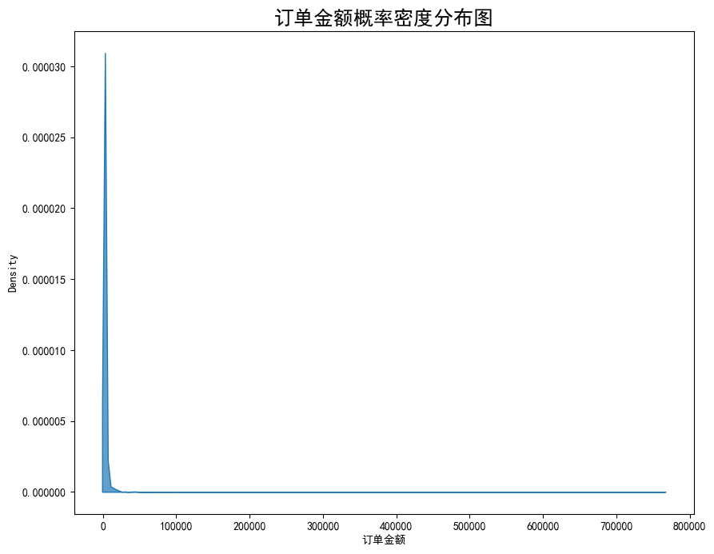

```python
plt.figure(figsize=(10,8),dpi=100)

sns.kdeplot(data.loc[:,"订单金额"],
           shade = True,
           label = "订单金额",
           alpha = 0.7)

plt.title("订单金额概率密度分布图",fontsize = 18)
plt.show()
```

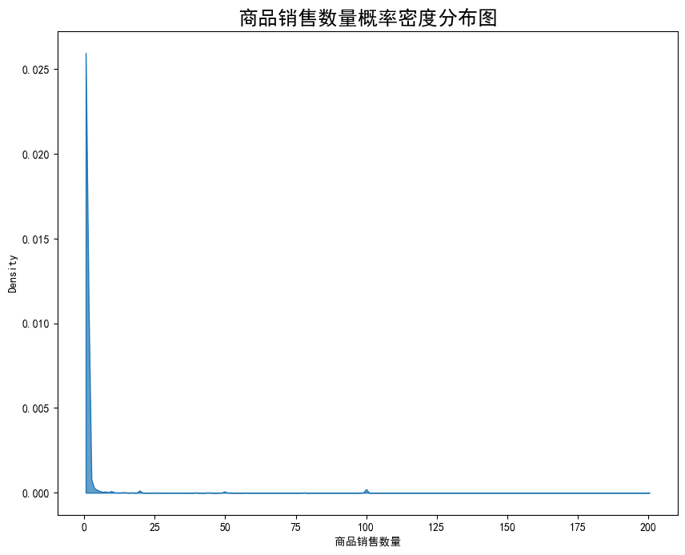

```python
plt.figure(figsize=(10,8),dpi=100)

sns.kdeplot(data.loc[:,"商品销售数量"],
           shade = True,
           label = "商品销售数量",
           alpha = 0.7)

plt.title("商品销售数量概率密度分布图",fontsize = 18)
plt.show()
```

### 使用箱线图判断异常值并计算标签相关性

QL:下四分位数，QU：上四分位数，IQR：QU-QL

当任意样本的特定特征值超出 [QL-1.5IQR, QU+1.5IQR]时，则认为该样本的该特征值是异常值

```python
Boxabnormal = []

for idx,col in enumerate(["订单金额","商品销售数量"]):
    feature = data.loc[:,col]
    QL = np.quantile(feature,0.25)
    QU = np.quantile(feature,0.75)
    IQR = QU - QL
    error = feature[((feature < QL-1.5*IQR).astype(int)+
                   (feature > QU+1.5*IQR).astype(int)) != 0]
    Boxabnormal.extend(error.index)
```

```python
Boxabnormal = set(Boxabnormal)
```

```python
print("共有{:d}条样本含有至少一条异常值，占总样本比例的{:.2f}%".format(len(Boxabnormal),100*len(Boxabnormal) / data.shape[0]))
print("异常样本中共有{:.2f}%的样本含有异常值".format(100*data.loc[Boxabnormal,"异常"].mean()))
```

```
共有29947条样本含有至少一条异常值，占总样本比例的22.81%
异常样本中共有24.60%的样本含有异常值
```

### 建立标记存在异常值的新特征，测试与标签的相关系数

```python
df = pd.DataFrame(index = data.index)
df["特征异常"] = 0
df.loc[Boxabnormal,"特征异常"] = 1
pd.concat([df["特征异常"],data["异常"]],axis=1).corr()
```

|  | 特征异常 | 异常 |
| --- | --- | --- |
| 特征异常 | 1.00000 | 0.04044 |
| 异常 | 0.04044 | 1.00000 |

结论：特征异常与实际交易异常之间几乎不存在关系，但是由于异常值样本量太大，我们暂时未对异常值进行删除或盖帽处理。由于我们使用树模型，后续可以考虑用分箱的方式去处理异常值。

### 数据清洗与预处理总结

1、缺失值：缺失值与交易异常无关，共删除1429条含有缺失值的样本，数据集不再含有缺失值。

2、重复值：共删除1483条含有重复值的样本，删除“日期特征”这个错误/人造特征。数据集不再含有重复值。同时，注意到一个订单ID下的所有样本的标签一致，可作为一个基本业务结论用于后续建立模型.

3、异常值：异常值与交易异常几乎无关，由于含有异常值的样本量太大，暂时未对异常值进行进一步处理，后续在特征工程部分考虑进行分箱处理。